# Fraudulent Transactions Prediction

Solution Engineering - R

Felix Erlacher, Merve Taskaya, Tomasz Wlodarski

May 14, 2023

# Einleitung

## Zielsetzung des Projekts

- Ziel des Projekts ist es, ein Modell zu entwickeln, welches die Wahrscheinlichkeit einer betrügerischen Transaktion vorhersagt.
- Die Daten stammen von Kaggle und beinhalten 6362620 Transaktionen, die in 30 Tagen simuliert wurden. <sup>1</sup>
[^1]: ‘Fraudulent Transactions Prediction’. https://www.kaggle.com/datasets/vardhansiramdasu/fraudulent-transactions-prediction (accessed May 14, 2023)

## qualitative Ziele

- Verbesserung der Effektivität der Betrugsprävention und -erkennung
- Steigerung der Kundenzufriedenheit und des Vertrauens in die Bank
- Verbesserung des Rufs der Bank durch proaktive Betrugsprävention
- Vermeidung von finanziellen Verlusten für Kunden und die Bank durch Betrug

# Datengrundlage

## Features

- step - maps a unit of time in the real world. In this case 1 step is 1 hour of time. Total steps 744 (30 days simulation).
- type - CASH-IN, CASH-OUT, DEBIT, PAYMENT and TRANSFER.
- amount - amount of the transaction in local currency.
- nameOrig - customer who started the transaction
- oldbalanceOrg - initial balance before the transaction
- newbalanceOrig - new balance after the transaction
- nameDest - customer who is the recipient of the transaction
- oldbalanceDest - initial balance recipient before the transaction. Note that there is not information for customers that start with M (Merchants).
- newbalanceDest - new balance recipient after the transaction. Note that there is not information for customers that start with M (Merchants).
- isFraud - This is the transactions made by the fraudulent agents inside the simulation. In this specific dataset the fraudulent behavior of the agents aims to profit by taking control or customers accounts and try to empty the funds by transferring to another account and then cashing out of the system.
- isFlaggedFraud - The business model aims to control massive transfers from one account to another and flags illegal attempts. An illegal attempt in this dataset is an attempt to transfer more than 200.000 in a single transaction.

‘Fraudulent Transactions Prediction’. https://www.kaggle.com/datasets/vardhansiramdasu/fraudulent-transactions-prediction (accessed May 14, 2023)

## Explorative Datenanalyse

```r
#read csv data/Fraud.csv into tibble with readr::read_csv for better performance & tidyverse support
fraud <- readr::read_csv ("data/Fraud.csv", )
fraud %>% glimpse()
```

```
Rows: 6,362,620
Columns: 11
$ step           <dbl> 1, 1, 1, 1, 1, 1, 1, 1, 1, 1, 1, 1, 1, 1, 1, 1, 1, 1, 1…
$ type           <chr> "PAYMENT", "PAYMENT", "TRANSFER", "CASH_OUT", "PAYMENT"…
$ amount         <dbl> 9839.64, 1864.28, 181.00, 181.00, 11668.14, 7817.71, 71…
$ nameOrig       <chr> "C1231006815", "C1666544295", "C1305486145", "C84008367…
$ oldbalanceOrg  <dbl> 170136.0, 21249.0, 181.0, 181.0, 41554.0, 53860.0, 1831…
$ newbalanceOrig <dbl> 160296.36, 19384.72, 0.00, 0.00, 29885.86, 46042.29, 17…
$ nameDest       <chr> "M1979787155", "M2044282225", "C553264065", "C38997010"…
$ oldbalanceDest <dbl> 0, 0, 0, 21182, 0, 0, 0, 0, 0, 41898, 10845, 0, 0, 0, 0…
$ newbalanceDest <dbl> 0.00, 0.00, 0.00, 0.00, 0.00, 0.00, 0.00, 0.00, 0.00, 4…
$ isFraud        <dbl> 0, 0, 1, 1, 0, 0, 0, 0, 0, 0, 0, 0, 0, 0, 0, 0, 0, 0, 0…
$ isFlaggedFraud <dbl> 0, 0, 0, 0, 0, 0, 0, 0, 0, 0, 0, 0, 0, 0, 0, 0, 0, 0, 0…
```

```r
introduce(fraud) %>% t()
```

```
                           [,1]
rows                    6362620
columns                      11
discrete_columns              3
continuous_columns            8
all_missing_columns           0
total_missing_values          0
complete_rows           6362620
total_observations     69988820
memory_usage         1140722824
```

## Überblick

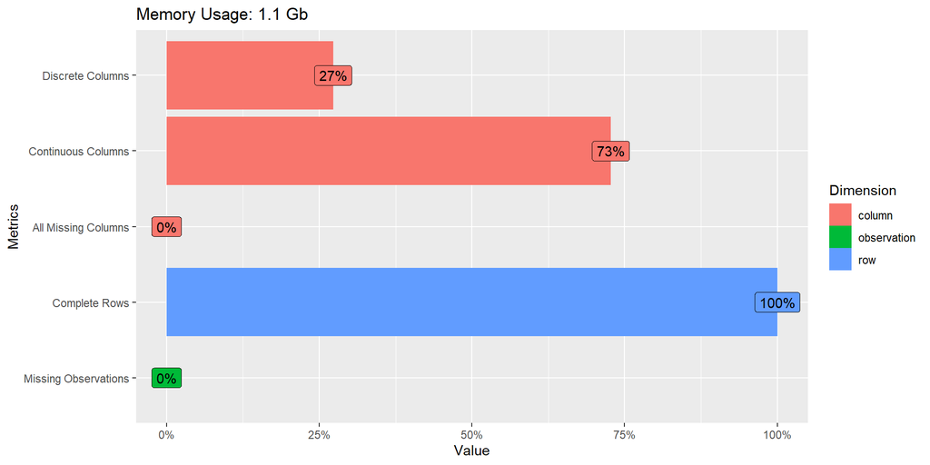

## Verteilung ausgewählter Features

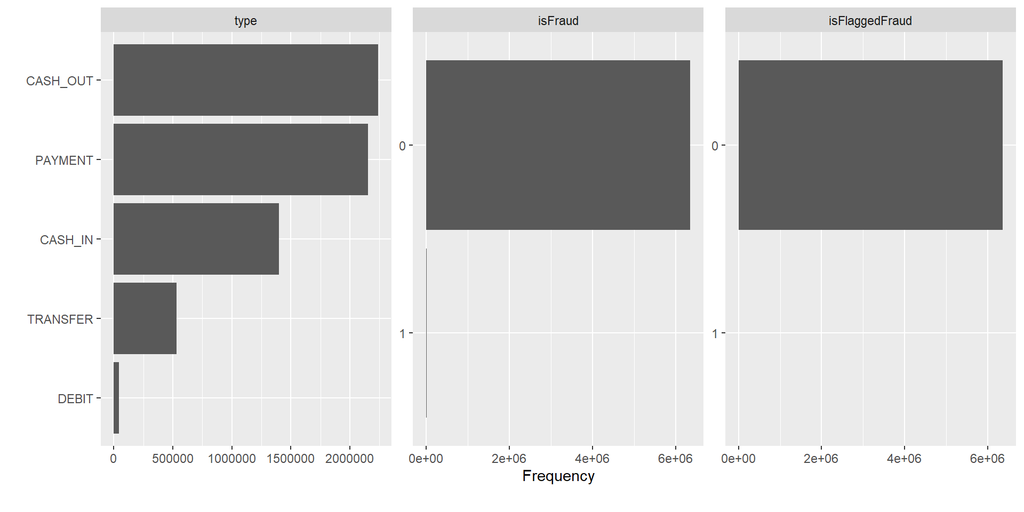

## Verteilung ausgewählter Features nach isFraud

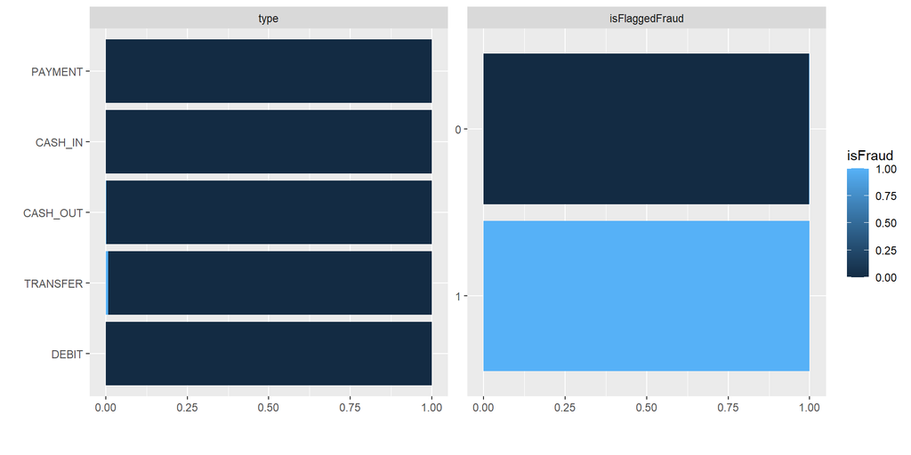

## Verteilung ausgewählter Features nach type

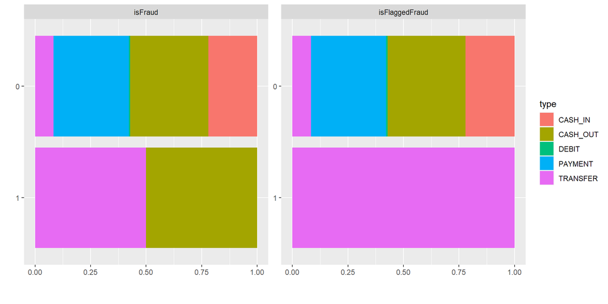

## Verteilung ausgewählter Features in Zahlen

```r
fraud %>% count(isFlaggedFraud, isFraud) %>% kable() #include zero
```

| isFlaggedFraud | isFraud | n |
| --- | --- | --- |
| 0 | 0 | 6354407 |
| 0 | 1 | 8197 |
| 1 | 1 | 16 |

```r
fraud %>% filter(isFlaggedFraud == 1 & isFraud == 0) %>% count()  %>% kable()
```

| n |
| --- |
| 0 |

## Korrelation

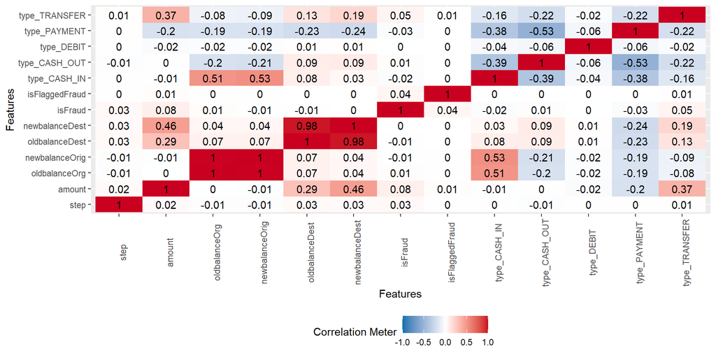

# Projektorganisation

## Aufgabenteilung

- Projektleiter: Koordination des Projektablaufs Verantwortung für das Erreichen der Projektziele Kommunikation mit dem Dozenten
- Projektmitglied 1: Datenaufbereitung und -bereinigung Durchführung von explorativen Datenanalysen Feature Engineering
- Projektmitglied 2: Entwicklung und Training des Modells Evaluation des Modells und Analyse der Performance Optimierung des Modells
- Projektmitglied 3: Dokumentation der Arbeitsschritte und Ergebnisse Erstellung der Abschlusspräsentation Beantwortung von Fragen des Dozenten

# Plan für die Ausarbeitung des Projekts (Workflow), Backlog

## Backlog

**Aufgabe**  
Datenaufbereitung und -bereinigung  
Explorative Datenanalyse  
Feature Engineering  
Modellentwicklung und Training  
Modellbewertung und Performance-Analyse  
Modelloptimierung  
Dokumentation der Arbeitsschritte und Ergebnisse  
Erstellung der Abschlusspräsentation

**Fälligkeitsdatum**  
16.05.2023  
16.05.2023  
16.05.2023  
16.05.2023  
16.05.2023  
16.05.2023  
16.05.2023  
16.05.2023